# ExtraaLearn Project

## Context

The EdTech industry has been surging in the past decade immensely, and according to a forecast, the Online Education market would be worth $286.62bn by 2023 with a compound annual growth rate (CAGR) of 10.26% from 2018 to 2023. The modern era of online education has enforced a lot in its growth and expansion beyond any limit. Due to having many dominant features like ease of information sharing, personalized learning experience, transparency of assessment, etc, it is now preferable to traditional education.

In the present scenario due to the Covid-19, the online education sector has witnessed rapid growth and is attracting a lot of new customers. Due to this rapid growth, many new companies have emerged in this industry. With the availability and ease of use of digital marketing resources, companies can reach out to a wider audience with their offerings. The customers who show interest in these offerings are termed as leads. There are various sources of obtaining leads for Edtech companies, like

- The customer interacts with the marketing front on social media or other online platforms.
- The customer browses the website/app and downloads the brochure
- The customer connects through emails for more information.

The company then nurtures these leads and tries to convert them to paid customers. For this, the representative from the organization connects with the lead on call or through email to share further details.

## Objective

ExtraaLearn is an initial stage startup that offers programs on cutting-edge technologies to students and professionals to help them upskill/reskill. With a large number of leads being generated on a regular basis, one of the issues faced by ExtraaLearn is to identify which of the leads are more likely to convert so that they can allocate resources accordingly. You, as a data scientist at ExtraaLearn, have been provided the leads data to:

- Analyze and build an ML model to help identify which leads are more likely to convert to paid customers,
- Find the factors driving the lead conversion process
- Create a profile of the leads which are likely to convert

## Data Description

The data contains the different attributes of leads and their interaction details with ExtraaLearn. The detailed data dictionary is given below.

**Data Dictionary**

- ID: ID of the lead
- age: Age of the lead
- current_occupation: Current occupation of the lead. Values include 'Professional','Unemployed',and 'Student'
- first_interaction: How did the lead first interacted with ExtraaLearn. Values include 'Website', 'Mobile App'
- profile_completed: What percentage of profile has been filled by the lead on the website/mobile app. Values include Low - (0-50%), Medium - (50-75%), High (75-100%)
- website_visits: How many times has a lead visited the website
- time_spent_on_website: Total time spent on the website
- page_views_per_visit: Average number of pages on the website viewed during the visits.
- last_activity: Last interaction between the lead and ExtraaLearn.
  - Email Activity: Seeking for details about program through email, Representative shared information with lead like brochure of program , etc
  - Phone Activity: Had a Phone Conversation with representative, Had conversation over SMS with representative, etc
  - Website Activity: Interacted on live chat with representative, Updated profile on website, etc
- print_media_type1: Flag indicating whether the lead had seen the ad of ExtraaLearn in the Newspaper.
- print_media_type2: Flag indicating whether the lead had seen the ad of ExtraaLearn in the Magazine.
- digital_media: Flag indicating whether the lead had seen the ad of ExtraaLearn on the digital platforms.
- educational_channels: Flag indicating whether the lead had heard about ExtraaLearn in the education channels like online forums, discussion threads, educational websites, etc.
- referral: Flag indicating whether the lead had heard about ExtraaLearn through reference.
- status: Flag indicating whether the lead was converted to a paid customer or not.

## Importing necessary libraries and data

```python
# Libraries to help with reading and manipulating data
import pandas as pd
import numpy as np

# Libaries to help with data visualization
import matplotlib.pyplot as plt
import seaborn as sns

# To tune model, get different metric scores, and split data
from sklearn import metrics
from sklearn.metrics import r2_score, mean_squared_error, mean_absolute_error

from sklearn.model_selection import train_test_split, StratifiedKFold, cross_val_score

# To be used for data scaling and one hot encoding
from sklearn.preprocessing import StandardScaler, MinMaxScaler, OneHotEncoder, LabelEncoder

# To impute missing values
from sklearn.impute import SimpleImputer

# Importing the Machine Learning models we require from Scikit-Learn
from sklearn import tree;
from sklearn.tree import DecisionTreeClassifier;
from sklearn.ensemble import RandomForestClassifier;

# To help with model building
from sklearn.tree import DecisionTreeRegressor
from sklearn.ensemble import (
    BaggingRegressor,
    RandomForestRegressor,
    GradientBoostingRegressor,
    AdaBoostRegressor,
    StackingRegressor,
)

# Importing the other functions we may require from Scikit-Learn
from sklearn.model_selection import train_test_split, GridSearchCV, RandomizedSearchCV;
from sklearn.metrics import recall_score, roc_curve, classification_report, confusion_matrix;
from sklearn.preprocessing import StandardScaler, LabelEncoder, OneHotEncoder;
from sklearn.compose import ColumnTransformer;
from sklearn.impute import SimpleImputer;
from sklearn.pipeline import Pipeline;
from sklearn import metrics, model_selection;

# To suppress warnings
import warnings

warnings.filterwarnings("ignore")
```

```python
# inserting original dataset

from google.colab import drive
drive.mount('/content/drive')
```

```python
data = pd.read_csv('/content/drive/My Drive/MIT DSS/Week 5/ExtraaLearn.csv')
```

## Data Overview

- Observations
- Sanity checks

```python
data.head()
```

|  | ID | age | current_occupation | first_interaction | profile_completed | website_visits | time_spent_on_website | page_views_per_visit | last_activity | print_media_type1 | print_media_type2 | digital_media | educational_channels | referral | status |
| --- | --- | --- | --- | --- | --- | --- | --- | --- | --- | --- | --- | --- | --- | --- | --- |
| 0 | EXT001 | 57 | Unemployed | Website | High | 7 | 1639 | 1.861 | Website Activity | Yes | No | Yes | No | No | 1 |
| 1 | EXT002 | 56 | Professional | Mobile App | Medium | 2 | 83 | 0.320 | Website Activity | No | No | No | Yes | No | 0 |
| 2 | EXT003 | 52 | Professional | Website | Medium | 3 | 330 | 0.074 | Website Activity | No | No | Yes | No | No | 0 |
| 3 | EXT004 | 53 | Unemployed | Website | High | 4 | 464 | 2.057 | Website Activity | No | No | No | No | No | 1 |
| 4 | EXT005 | 23 | Student | Website | High | 4 | 600 | 16.914 | Email Activity | No | No | No | No | No | 0 |

```python
data.tail()
```

|  | ID | age | current_occupation | first_interaction | profile_completed | website_visits | time_spent_on_website | page_views_per_visit | last_activity | print_media_type1 | print_media_type2 | digital_media | educational_channels | referral | status |
| --- | --- | --- | --- | --- | --- | --- | --- | --- | --- | --- | --- | --- | --- | --- | --- |
| 4607 | EXT4608 | 35 | Unemployed | Mobile App | Medium | 15 | 360 | 2.170 | Phone Activity | No | No | No | Yes | No | 0 |
| 4608 | EXT4609 | 55 | Professional | Mobile App | Medium | 8 | 2327 | 5.393 | Email Activity | No | No | No | No | No | 0 |
| 4609 | EXT4610 | 58 | Professional | Website | High | 2 | 212 | 2.692 | Email Activity | No | No | No | No | No | 1 |
| 4610 | EXT4611 | 57 | Professional | Mobile App | Medium | 1 | 154 | 3.879 | Website Activity | Yes | No | No | No | No | 0 |
| 4611 | EXT4612 | 55 | Professional | Website | Medium | 4 | 2290 | 2.075 | Phone Activity | No | No | No | No | No | 0 |

```python
print("Number of duplicates:", data.duplicated().sum())
print('-' * 40)
print(data.isnull().sum())
```

```
Number of duplicates: 0
----------------------------------------
ID                       0
age                      0
current_occupation       0
first_interaction        0
profile_completed        0
website_visits           0
time_spent_on_website    0
page_views_per_visit     0
last_activity            0
print_media_type1        0
print_media_type2        0
digital_media            0
educational_channels     0
referral                 0
status                   0
dtype: int64
```

No duplicates and no missing values (NaN) found in the original dataset.

```python
data.shape
```

```
(4612, 15)
```

Original dataset has 4612 observations, each have 15 features.

Some of the features are futile in predictive analyses, so we are going to drop them and create a new dataset called `df`.

## Exploratory Data Analysis (EDA)

- EDA is an important part of any project involving data.
- It is important to investigate and understand the data better before building a model with it.
- A few questions have been mentioned below which will help you approach the analysis in the right manner and generate insights from the data.
- A thorough analysis of the data, in addition to the questions mentioned below, should be done.

```python
# copied dataset, so changes will not be made to original dataset
df = data.copy()
```

```python
df.info()
```

```
<class 'pandas.core.frame.DataFrame'>
RangeIndex: 4612 entries, 0 to 4611
Data columns (total 15 columns):
 #   Column                 Non-Null Count  Dtype
---  ------                 --------------  -----
 0   ID                     4612 non-null   object
 1   age                    4612 non-null   int64
 2   current_occupation     4612 non-null   object
 3   first_interaction      4612 non-null   object
 4   profile_completed      4612 non-null   object
 5   website_visits         4612 non-null   int64
 6   time_spent_on_website  4612 non-null   int64
 7   page_views_per_visit   4612 non-null   float64
 8   last_activity          4612 non-null   object
 9   print_media_type1      4612 non-null   object
 10  print_media_type2      4612 non-null   object
 11  digital_media          4612 non-null   object
 12  educational_channels   4612 non-null   object
 13  referral               4612 non-null   object
 14  status                 4612 non-null   int64
dtypes: float64(1), int64(4), object(10)
memory usage: 540.6+ KB
```

`ID` is not useful in our case, so we are going to remove it.

Many of our features are type `object`, meaning they contain string and are categorical variables (i.e. either binary or multiple-class variables).

We are going to have to transform these variables into numerical ones, in order to be able to utilize decision tree and random forest models.

```python
df = df.drop(["ID"], axis=1)
```

Let's define a new df named `df_categorical`.

```python
df_categorical = np.array([ 'current_occupation', 'first_interaction', 'profile_completed',
       'last_activity', 'print_media_type1', 'print_media_type2', 'digital_media', 'educational_channels',
       'referral'])
```

```python
for i in df_categorical:
  print(df[i].value_counts())
  print('-' * 40)
```

```
Professional    2616
Unemployed      1441
Student          555
Name: current_occupation, dtype: int64
----------------------------------------
Website       2542
Mobile App    2070
Name: first_interaction, dtype: int64
----------------------------------------
High      2264
Medium    2241
Low        107
Name: profile_completed, dtype: int64
----------------------------------------
Email Activity      2278
Phone Activity      1234
Website Activity    1100
Name: last_activity, dtype: int64
----------------------------------------
No     4115
Yes     497
Name: print_media_type1, dtype: int64
----------------------------------------
No     4379
Yes     233
Name: print_media_type2, dtype: int64
----------------------------------------
No     4085
Yes     527
Name: digital_media, dtype: int64
----------------------------------------
No     3907
Yes     705
Name: educational_channels, dtype: int64
----------------------------------------
No     4519
Yes      93
Name: referral, dtype: int64
----------------------------------------
```

We can now see each category for our categorical variables, and we will ignore our numerical variables for now. Let us now make them numerical.

We will encode the variables as follows:

- create two dummies out of `current_occupation`: *professional* and *unemployed*
- `first_interaction` will be coded as 1 for *Website* and 0 for *Mobile App*
- `profile_completed` as 0, 1, 2 in order from '*Low*' to '*High*'
- create two dummies out of `last_activity`: *email* and *phone*
- `print_media_type1` as 0 or 1, if yes or no
- `print_media_type2` as 0 or 1, if yes or no
- `digital_media` as 0 or 1, if yes or no
- `educational_channels` as 0 or 1, if yes or no
- `referral` as 0 or 1, if yes or no

For `profile_completed`:

```python
# Define a mapping dictionary, so that we can see what category gets what number
# this is done manually, although it can be done using an encoder
mapping_profile_completed = {'Low': 0, 'Medium': 1, 'High': 2}

# Map the categories to numerical values
encoded_categories_profile_completed = [mapping_profile_completed[category] for category in df['profile_completed']]

df['profile_completed'] = encoded_categories_profile_completed

print(df['profile_completed'])
```

```
0       2
1       1
2       1
3       2
4       2
       ..
4607    1
4608    1
4609    2
4610    1
4611    1
Name: profile_completed, Length: 4612, dtype: int64
```

For `current_occupation` and `last_activity`:

```python
# current_occupation: creating professional and unemployed

df['professional']=0
df.loc[(df['current_occupation'] == 'Professional'), 'professional'] = 1

df['unemployed']=0
df.loc[(df['current_occupation'] == 'Unemployed'), 'unemployed'] = 1

# last_activity: creating email and phone

df['email']=0
df.loc[(df['last_activity'] == 'Email Activity'), 'email'] = 1

df['phone']=0
df.loc[(df['last_activity'] == 'Phone Activity'), 'phone'] = 1
```

For all other categorical variables:

```python
# first_interaction

mapping_first_interaction = {'Mobile App': 0, 'Website': 1}

df['first_interaction'] = [mapping_first_interaction[category] for category in df['first_interaction']]

# print_media_type1, print_media_type2, digital_media, educational_channels, referral

mapping_other = {'No': 0, 'Yes': 1}

df_categorical_other = np.array([ 'print_media_type1', 'print_media_type2', 'digital_media', 'educational_channels',
       'referral'])

for i in df_categorical_other:
  df[i] = [mapping_other[category] for category in df[i]]
```

Let's drop `current_occupation` and `last_activity` and see how our df looks like:

```python
df = df.drop(["current_occupation", "last_activity"], axis=1)

df.head(15)
```

|  | age | first_interaction | profile_completed | website_visits | time_spent_on_website | page_views_per_visit | print_media_type1 | print_media_type2 | digital_media | educational_channels | referral | status | professional | unemployed | email | phone |
| --- | --- | --- | --- | --- | --- | --- | --- | --- | --- | --- | --- | --- | --- | --- | --- | --- |
| 0 | 57 | 1 | 2 | 7 | 1639 | 1.861 | 1 | 0 | 1 | 0 | 0 | 1 | 0 | 1 | 0 | 0 |
| 1 | 56 | 0 | 1 | 2 | 83 | 0.320 | 0 | 0 | 0 | 1 | 0 | 0 | 1 | 0 | 0 | 0 |
| 2 | 52 | 1 | 1 | 3 | 330 | 0.074 | 0 | 0 | 1 | 0 | 0 | 0 | 1 | 0 | 0 | 0 |
| 3 | 53 | 1 | 2 | 4 | 464 | 2.057 | 0 | 0 | 0 | 0 | 0 | 1 | 0 | 1 | 0 | 0 |
| 4 | 23 | 1 | 2 | 4 | 600 | 16.914 | 0 | 0 | 0 | 0 | 0 | 0 | 0 | 0 | 1 | 0 |
| 5 | 50 | 0 | 2 | 4 | 212 | 5.682 | 0 | 0 | 0 | 1 | 0 | 0 | 0 | 1 | 0 | 1 |
| 6 | 56 | 0 | 1 | 13 | 625 | 2.015 | 0 | 0 | 1 | 0 | 0 | 1 | 1 | 0 | 0 | 0 |
| 7 | 57 | 0 | 1 | 2 | 517 | 2.985 | 0 | 0 | 0 | 0 | 0 | 0 | 1 | 0 | 1 | 0 |
| 8 | 57 | 0 | 2 | 2 | 2231 | 2.194 | 0 | 0 | 1 | 0 | 0 | 1 | 1 | 0 | 0 | 1 |
| 9 | 59 | 0 | 2 | 1 | 1819 | 3.513 | 0 | 0 | 0 | 0 | 0 | 0 | 1 | 0 | 0 | 1 |
| 10 | 52 | 1 | 1 | 2 | 433 | 2.140 | 0 | 0 | 0 | 0 | 0 | 1 | 1 | 0 | 1 | 0 |
| 11 | 57 | 1 | 2 | 3 | 616 | 3.485 | 1 | 1 | 0 | 0 | 0 | 1 | 1 | 0 | 0 | 0 |
| 12 | 35 | 1 | 2 | 4 | 239 | 2.214 | 0 | 0 | 0 | 0 | 0 | 0 | 1 | 0 | 0 | 1 |
| 13 | 23 | 1 | 2 | 3 | 115 | 2.690 | 0 | 0 | 0 | 0 | 0 | 0 | 0 | 0 | 1 | 0 |
| 14 | 56 | 1 | 2 | 6 | 358 | 0.279 | 0 | 0 | 0 | 0 | 0 | 0 | 1 | 0 | 1 | 0 |

```python
df.shape
```

```
(4612, 16)
```

```python
# Saving our new df

df_1 = df.copy()
```

## Data Preprocessing

```python
df_1.describe().T
```

|  | count | mean | std | min | 25% | 50% | 75% | max |
| --- | --- | --- | --- | --- | --- | --- | --- | --- |
| age | 4612.0 | 46.201214 | 13.161454 | 18.0 | 36.00000 | 51.000 | 57.00000 | 63.000 |
| first_interaction | 4612.0 | 0.551171 | 0.497429 | 0.0 | 0.00000 | 1.000 | 1.00000 | 1.000 |
| profile_completed | 4612.0 | 1.467693 | 0.543526 | 0.0 | 1.00000 | 1.000 | 2.00000 | 2.000 |
| website_visits | 4612.0 | 3.566782 | 2.829134 | 0.0 | 2.00000 | 3.000 | 5.00000 | 30.000 |
| time_spent_on_website | 4612.0 | 724.011275 | 743.828683 | 0.0 | 148.75000 | 376.000 | 1336.75000 | 2537.000 |
| page_views_per_visit | 4612.0 | 3.026126 | 1.968125 | 0.0 | 2.07775 | 2.792 | 3.75625 | 18.434 |
| print_media_type1 | 4612.0 | 0.107762 | 0.310114 | 0.0 | 0.00000 | 0.000 | 0.00000 | 1.000 |
| print_media_type2 | 4612.0 | 0.050520 | 0.219040 | 0.0 | 0.00000 | 0.000 | 0.00000 | 1.000 |
| digital_media | 4612.0 | 0.114267 | 0.318170 | 0.0 | 0.00000 | 0.000 | 0.00000 | 1.000 |
| educational_channels | 4612.0 | 0.152862 | 0.359894 | 0.0 | 0.00000 | 0.000 | 0.00000 | 1.000 |
| referral | 4612.0 | 0.020165 | 0.140579 | 0.0 | 0.00000 | 0.000 | 0.00000 | 1.000 |
| status | 4612.0 | 0.298569 | 0.457680 | 0.0 | 0.00000 | 0.000 | 1.00000 | 1.000 |
| professional | 4612.0 | 0.567216 | 0.495515 | 0.0 | 0.00000 | 1.000 | 1.00000 | 1.000 |
| unemployed | 4612.0 | 0.312446 | 0.463541 | 0.0 | 0.00000 | 0.000 | 1.00000 | 1.000 |
| email | 4612.0 | 0.493929 | 0.500017 | 0.0 | 0.00000 | 0.000 | 1.00000 | 1.000 |
| phone | 4612.0 | 0.267563 | 0.442736 | 0.0 | 0.00000 | 0.000 | 1.00000 | 1.000 |

For aesthetic and organizational purposes, let's put status (our target variable) as the first variable in the dataset

```python
df_1 = df_1.rename({'status':'a_status'}, axis=1)

df_1 = df_1.reindex(sorted(df_1.columns), axis=1)

df_1 = df_1.rename({'a_status':'status'}, axis=1)
```

```python
df_1
```

|  | status | age | digital_media | educational_channels | email | first_interaction | page_views_per_visit | phone | print_media_type1 | print_media_type2 | professional | profile_completed | referral | time_spent_on_website | unemployed | website_visits |
| --- | --- | --- | --- | --- | --- | --- | --- | --- | --- | --- | --- | --- | --- | --- | --- | --- |
| 0 | 1 | 57 | 1 | 0 | 0 | 1 | 1.861 | 0 | 1 | 0 | 0 | 2 | 0 | 1639 | 1 | 7 |
| 1 | 0 | 56 | 0 | 1 | 0 | 0 | 0.320 | 0 | 0 | 0 | 1 | 1 | 0 | 83 | 0 | 2 |
| 2 | 0 | 52 | 1 | 0 | 0 | 1 | 0.074 | 0 | 0 | 0 | 1 | 1 | 0 | 330 | 0 | 3 |
| 3 | 1 | 53 | 0 | 0 | 0 | 1 | 2.057 | 0 | 0 | 0 | 0 | 2 | 0 | 464 | 1 | 4 |
| 4 | 0 | 23 | 0 | 0 | 1 | 1 | 16.914 | 0 | 0 | 0 | 0 | 2 | 0 | 600 | 0 | 4 |
| ... | ... | ... | ... | ... | ... | ... | ... | ... | ... | ... | ... | ... | ... | ... | ... | ... |
| 4607 | 0 | 35 | 0 | 1 | 0 | 0 | 2.170 | 1 | 0 | 0 | 0 | 1 | 0 | 360 | 1 | 15 |
| 4608 | 0 | 55 | 0 | 0 | 1 | 0 | 5.393 | 0 | 0 | 0 | 1 | 1 | 0 | 2327 | 0 | 8 |
| 4609 | 1 | 58 | 0 | 0 | 1 | 1 | 2.692 | 0 | 0 | 0 | 1 | 2 | 0 | 212 | 0 | 2 |
| 4610 | 0 | 57 | 0 | 0 | 0 | 0 | 3.879 | 0 | 1 | 0 | 1 | 1 | 0 | 154 | 0 | 1 |
| 4611 | 0 | 55 | 0 | 0 | 0 | 1 | 2.075 | 1 | 0 | 0 | 1 | 1 | 0 | 2290 | 0 | 4 |

4612 rows × 16 columns

Saving our new and final df to `df_clean`

```python
df_clean = df_1.copy()
```

## EDA

Histograms give us a good view of the distribution of data:

- `status`: 70-30 percent split, where most leads included in the dataset were not converted to customers
- `age`: left skewness, meaning most leads (and potentially future customers) tend to be older
- `digital media`: only 1 in 10 people have learned about the firm through digital platforms
- `educational_channels`: around 1 in 6 people have learned about the firm through educational channels (i.e. online forums, discussion threads, educational websites, etc.)
- `email, phone, first_interaction`: half of all leads have most recently interacted with the platform from **emails**, while the rest have either done so through the **phone** or **website**. 55 percent of people have however initially learned about ExtraaLearn through its **website**, while 45% through its **mobile app**
- `professional, unemployed`: more than half of leads are people in the workforce, the rest of them are not. Only 12 percent of this audience are actually **students**.
- `print_media_type1, print_media_type2`: few people have seen the startup mentioned in print media (10 and 5 percent on **Newspaper** and **Magazine**, respectively)
- `profile_completed`: almost all leads, 98 percent of them, have finished or are on the process of completing their profiles.
- `page_views_per_visit`: on average, people view three pages on the website
- `website_visits`: on average, people visit the website three times
- `time_spent_on_website`: people spend around 12 minutes on average browsing the website
- `referral`: "passing the word" has not really worked out for the startup. Very few people claim they were referred from someone about ExtraaLearn.

Listed below each histogram is a `value_counts` function that better indicates the frequency (in %) of the respective feature's values.

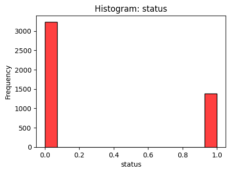

```
0    70.143105
1    29.856895
Name: status, dtype: float64
------------------------------------------------------------
```

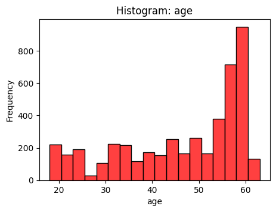

```
57    8.347788
58    8.282741
56    7.155247
59    7.111882
60    5.160451
55    4.336513
32    4.076323
53    1.973114
24    1.951431
43    1.929748
48    1.908066
51    1.908066
54    1.908066
49    1.886383
21    1.864701
```

[output cut: 33 more lines]

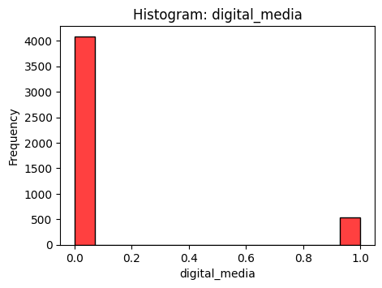

```
0    88.573287
1    11.426713
Name: digital_media, dtype: float64
------------------------------------------------------------
```

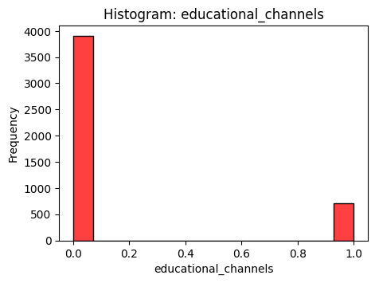

```
0    84.71379
1    15.28621
Name: educational_channels, dtype: float64
------------------------------------------------------------
```

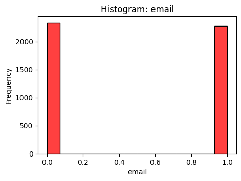

```
0    50.607112
1    49.392888
Name: email, dtype: float64
------------------------------------------------------------
```

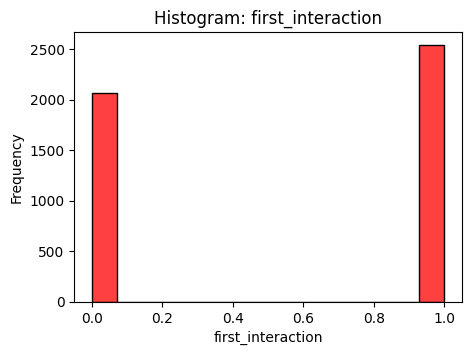

```
1    55.117086
0    44.882914
Name: first_interaction, dtype: float64
------------------------------------------------------------
```

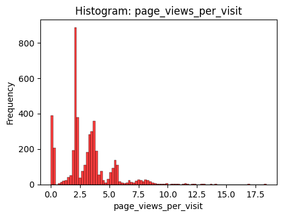

```
0.000    3.924545
2.168    0.303556
2.154    0.281873
2.200    0.260191
2.170    0.238508
           ...
5.793    0.021683
4.944    0.021683
5.624    0.021683
1.413    0.021683
2.692    0.021683
Name: page_views_per_visit, Length: 2414, dtype: float64
------------------------------------------------------------
```

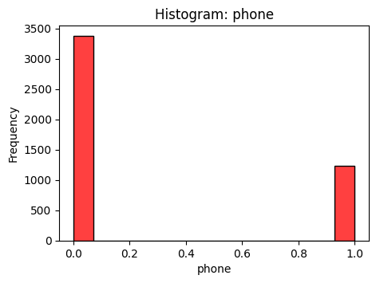

```
0    73.243712
1    26.756288
Name: phone, dtype: float64
------------------------------------------------------------
```

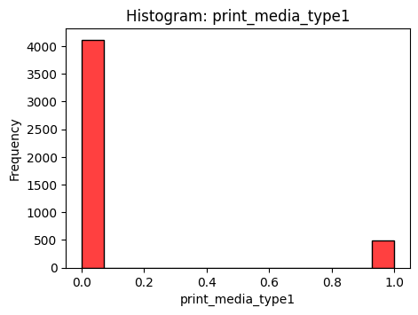

```
0    89.223764
1    10.776236
Name: print_media_type1, dtype: float64
------------------------------------------------------------
```

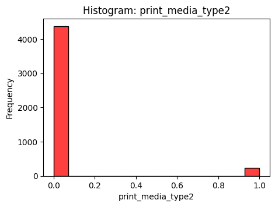

```
0    94.947962
1     5.052038
Name: print_media_type2, dtype: float64
------------------------------------------------------------
```

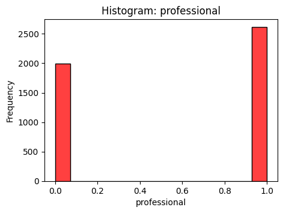

```
1    56.721596
0    43.278404
Name: professional, dtype: float64
------------------------------------------------------------
```

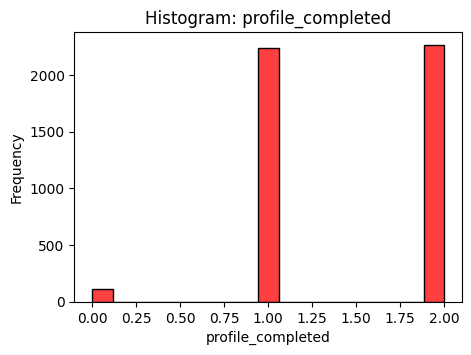

```
2    49.089332
1    48.590633
0     2.320035
Name: profile_completed, dtype: float64
------------------------------------------------------------
```

[4 more figures not shown]

```
2     26.647875
1     16.370338
3     13.898526
4     10.711188
5      9.150043
6      6.114484
7      5.030356
0      3.772767
8      3.274068
9      1.691240
10     0.737207
11     0.628794
12     0.542064
13     0.498699
14     0.368604
15     0.195143
24     0.065048
16     0.065048
25     0.043365
20     0.043365
30     0.021683
18     0.021683
27     0.021683
21     0.021683
17     0.021683
19     0.021683
29     0.021683
Name: website_visits, dtype: float64
------------------------------------------------------------
```

```python
# Histogram

for i in df_clean.columns:
  plt.figure(figsize=(5,3.5))
  plt.title(f'Histogram: {i}')
  plt.xlabel(i)
  plt.ylabel('Frequency')
  sns.histplot(data=df_clean, x=i, color='red', kde=False, palette="winter")
  plt.show();
  print(df_clean[i].value_counts(1)*100)
  print('-' * 60)
```

Boxplots also give great visual representation of data as well. It seems here that we have outliers mostly in continous variables, like: `page_views_per_visit` and `website_visits`.

These can be dealt with in various ways; either by replacing them with the feature's mean value or by removing them altogether (that is, if only the sample size is large enough and not fairly reduced).

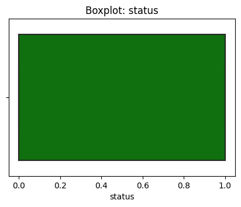

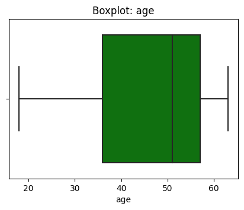

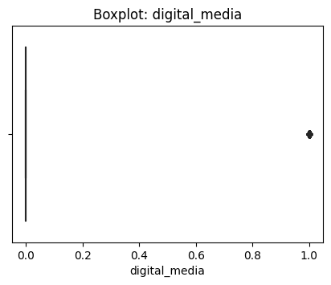

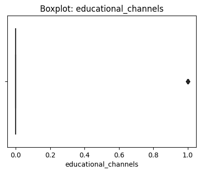

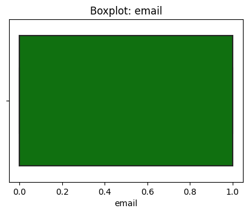

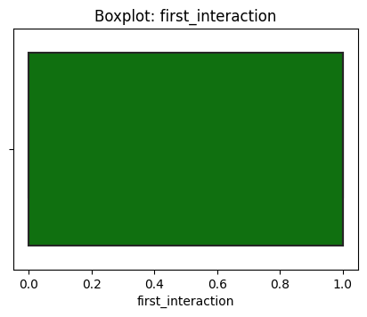

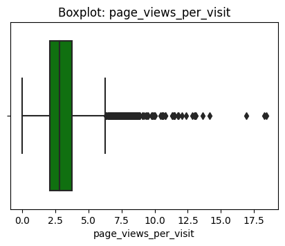

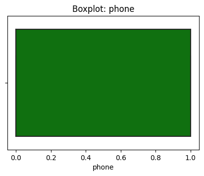

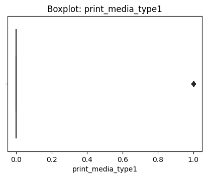

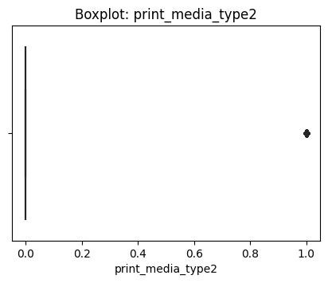

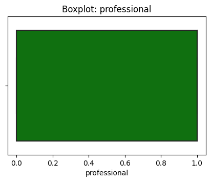

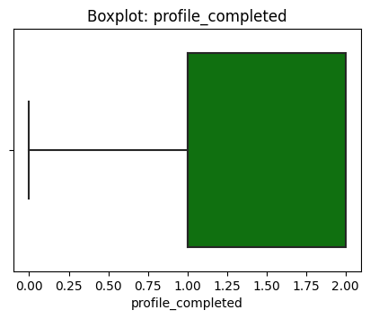

[4 more figures not shown]

```python
# Boxplot

for i in df_clean.columns:
  plt.figure(figsize=(5,3.5))
  plt.title(f'Boxplot: {i}')
  plt.xlabel(i)
  sns.axes_style('whitegrid')
  sns.boxplot(data=df_clean, x=i, color='green');
```